# CS236605: Deep Learning on Computational Accelerators

# Homework Assignment 1

Faculty of Computer Science, Technion.

Submitted by:

| # | Name | Id | email |
| --- | --- | --- | --- |
| Student 1 | [Alon de Jager] | [205797368] | [alonde-jager@campus.technion.ac.il] |
| Student 2 | [ben banuz] | [207570573] | [benbanuz@campus.technion.ac.il] |

## Introduction

In this first homework assignment we'll familiarize ourselves with `PyTorch` as a general-purpose tensor library with automatic gradient calculation capabilities. We'll use it to implement some traditional machine-learning algorithms and remind ourselves about basic concepts such as different data sets and their uses, model hyperparameters, cross-validation, loss functions and gradient derivation. We'll also familiarize ourselves with other highly important python machine learning packages such as `numpy`, `sklearn` and `pandas`.

## General Guidelines

- Please read the [getting started page](https://vistalab-technion.github.io/cs236605/assignments/getting-started/) on the course website. It explains how to **setup, run and submit** the assignment.
- The text and code cells in these notebooks are intended to guide you through the assignment and help you verify your solutions. The notebooks **do not need to be edited** at all (unless you wish to play around). The only exception is to fill your name(s) in the above cell before submission. Please do not remove sections or change the order of any cells.
- All your code (and even answers to questions) should be written in the files within the python package corresponding the assignment number (`hw1`, `hw2`, etc). You can of course use any editor or IDE to work on these files.

## Contents

- Part 1: Working with data in `PyTorch`
  - Datasets
  - Built-in Datasets and Transforms
  - `DataLoader`s and `Sampler`s
  - Training, Validation and Test Sets
- Part 2: Nearest-neighbor image classification:
  - kNN Classification
  - Cross-validation
- Part 3: Multiclass linear classification
  - Linear Classification
  - Loss Functions
  - Optimizing a Loss Function with Gradient Descent
  - Training the model with SGD
  - Automatic differentiation
- Part 4: Linear Regression
  - Dataset exploration
  - Linear Regression Model
  - Adding nonlinear features
  - Generalization

## Part 1: Working with data in `PyTorch`

In this part, we'll learn about the `Dataset` and `DataLoader` classes which are part of `PyTorch`'s `torch.util.data` package. These are highly useful abstractions that can greatly reduce the amount of boilerplate code you need to write in order to work with data. Knowing how to use these classes properly will prove useful in the coming assignments and course project.

```python
import torch
import torchvision
import numpy as np
import matplotlib.pyplot as plt
import unittest

%matplotlib inline
%load_ext autoreload
%autoreload 2

plt.rcParams.update({'font.size': 12})
torch.random.manual_seed(1904)
test = unittest.TestCase()
```

### Datasets

The `Dataset` class is an abstraction over a sequence of python objects, each representing a sample (with or without a label). it's main purpose is to load a single (possibly labeled) sample from some soure (disk, web, etc) into memory, and transform it into a usuable representation (e.g. image to tensor).

The `Dataset` abstracts away exactly when the data is loaded into memory: It can be on demand when each sample is accessed, all in advance or some combination using e.g. caching. This is implementation-specific.

Lets create a demonstration `Dataset` that returns noise images. It should:

- Return random tensors of size `CxWxH`.
- Label each returned tensor with a class label, an integer between `0` and `num_classes-1`.
- Initialize each returned tensor with a uniform distribution on `[0, 255]`.
- Return a total of `num_samples` labeled images.

**TODO** Implement the `RandomImageDataset` class in the `hw1/datasets.py` module. Use the code below to test your implementation.

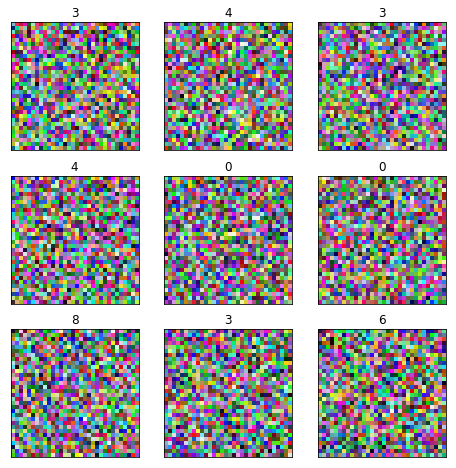

```python
# Test RandomImageDataset

import itertools
import cs236605.plot as plot
import hw1.datasets as hw1datasets

# Create the dataset
num_samples = 1000
num_classes = 10
image_size = (3, 32, 32)
ds = hw1datasets.RandomImageDataset(num_samples, num_classes, *image_size)

# You can load individual items from the dataset by indexing
img0, cls0 = ds[0]

# Plot first N images from the dataset with a helper function
fig, axes = plot.dataset_first_n(ds, 9, show_classes=True, nrows=3)
```

### Built-in Datasets and Transforms

Now that we've created a simple `Dataset` to see how they work, we'll load one of `pytorch`'s built-in datasets: CIFAR-10. This is a famous dataset consisting of 60,000 small `32x32` images classified into 10 classes. You can read more about it [here](https://www.cs.toronto.edu/~kriz/cifar.html).

The `torchvision` package has built-in `Dataset` classes that can download the data to a local folder, load it, transform it using arbitrary transform functions and iterate over the resulting samples.

Run the following code block to download and create a CIFAR-10 `Dataset`. It won't be downloaded again if already present.

```
Files already downloaded and verified
Number of samples: 50000
```

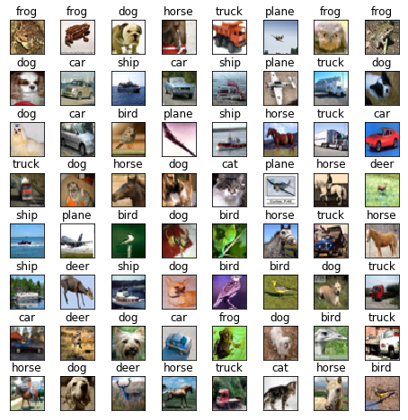

```python
import torchvision
import torchvision.transforms as tvtf

cfar10_labels = ('plane', 'car', 'bird', 'cat', 'deer', 'dog', 'frog', 'horse', 'ship', 'truck')

cifar10_train_ds = torchvision.datasets.CIFAR10(
    root='./data/cifar-10/', download=True, train=True,
    transform=tvtf.ToTensor() # Convert PIL image to pytorch Tensor
)

print('Number of samples:', len(cifar10_train_ds))

# Plot them with a helper function
fig, axes = plot.dataset_first_n(cifar10_train_ds, 64,
                                 show_classes=True, class_labels=cfar10_labels,
                                 nrows=8, hspace=0.5)
```

Now that we've loaded the entire CIFAR-10 dataset, we would want to work with a smaller subset from it to reduce runtime of the code in this notebook. A simple way to achieve this with `Datasets` is to wrap a `Dataset` in another `Dataset` that does this for us. This will make it easy to use our subset with `DataLoader`s as you will see later.

**TODO** Complete the implementation of `SubsetDataset` in `hw1/datasets.py` and use the following code block to test.

```python
subset_len = 5000
subset_offset = 1234
cifar10_train_subset_ds = hw1datasets.SubsetDataset(cifar10_train_ds, subset_len, subset_offset)

dataset_x, dataset_y  = cifar10_train_ds[subset_offset + 10]
subset_x, subset_y  = cifar10_train_subset_ds[10]

# Tests
test.assertEqual(len(cifar10_train_subset_ds), subset_len)
test.assertTrue(torch.all(dataset_x == subset_x))
test.assertEqual(dataset_y, subset_y)
with test.assertRaises(IndexError, msg="Out of bounds index should raise IndexError"):
    tmp = cifar10_train_subset_ds[subset_len]
```

### `DataLoader`s and `Sampler`s

We have seen that a `Dataset` is simply an iterable returning samples by index. Simple to implement, but not very powerful. The real benefit is when combining them with `DataLoader`. A `DataLoader` samples a batch of samples from the dataset according to logic defined by a `Sampler` object. The sampler decides how to partition the dataset into batches of `N` samples. The `DataLoader` additionally handles loading samples in parallel to speed up creation of a batch.

A major motivation here is memory usage. When combining a `DataLoader` with a `Dataset` we can easily control memory constraints by simple setting the batch size. This is important since large datasets (e.g. ImageNet) may not fit in memory of most machines. Since a `Dataset` can lazily load samples from disk on access, and the `DataLoader` can sample random samples from it in parallel, we are provided with a simple yet high-performance mechanism to iterate over random batches from our dataset without needing to hold all of it in memory.

Let's create a basic `DataLoader` for our CIFAR-10 dataset. Run the follwing code block multiple times and observe that different samples are shown each time in the first few batches.

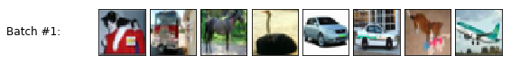

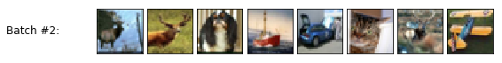

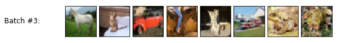

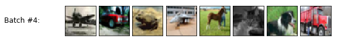

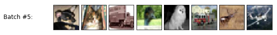

```python
# Create a simple DataLoader that partitions the data into batches
# of size N=8 in random order, using two background proceses
cifar10_train_dl = torch.utils.data.DataLoader(
    cifar10_train_ds, batch_size=8, shuffle=True, num_workers=2
)

# Iterate over batches sampled with our DataLoader
num_batches_to_show = 5
for idx, (images, classes) in enumerate(cifar10_train_dl):
    # The DataLoader returns a tuple of:
    # images: Tensor of size NxCxWxH
    # classes: Tensor of size N
    fig, axes = plot.tensors_as_images(images, figsize=(8, 1))
    fig.suptitle(f'Batch #{idx+1}:', x=0, y=0.6)
    if idx >= num_batches_to_show - 1:
        break
```

### Training, Validation and Test Sets

Now that we know about `DataLoaders` we can use them to do something useful: split a training dataset into **Training and Validation** sets.

A common issue with machine learning models is abundance of hyperparameters that must be selected prior to training the model on data. More generally, multiple different models, or hypothesis classes could be fitted to the data. We would like to determine which model and/or hyperparameter selection of the same model can best fit the training data we have.

How are such hyperparameters selected? How should their fitness be evaluated?

While tempting, we can't use our test dataset to determine this. Doing so would be effectively equivalent to training with the test set, and may significantly bias our model towards overfitting, reducing it's generalization ability.

A prevalent approach is therefore to split the training dataset into two parts: One for actual training, i.e. tuning model parameters e.g. weights in the case of neural nets, and another for validation, i.e. comparing one model or set of hyperparameters to another. After the best model is selected (by seeking the minimal validation error), it can be retrained with the entire training set.

Crucially, test set performance is only evaluated once, at the end, after the best model has been selected and trained on the full training set. This provides us with an unbiased estimate of how our model will generalize to previously-unseen data.

[figure not shown]

**TODO** Implement the function `create_train_validation_loaders` in the `hw1/dataloaders.py` module. Use the following code block to check your implementation. Hint: you can specify a sampler class for the `DataLoader` instance you create.

```python
# Testing the train/validation split dataloaders
import hw1.dataloaders as hw1dataloaders

validation_ratio = 0.2
dl_train, dl_valid = hw1dataloaders.create_train_validation_loaders(cifar10_train_ds, validation_ratio)

train_idx = set(dl_train.sampler.indices)
valid_idx = set(dl_valid.sampler.indices)
train_size = len(train_idx)
valid_size = len(valid_idx)
print('Training set size: ', train_size)
print('Validation set size: ', valid_size)

# Tests
test.assertEqual(train_size+valid_size, len(cifar10_train_ds), "Incorrect total number of samples")
test.assertEqual(valid_size, validation_ratio * (train_size + valid_size), "Incorrect ratio")
test.assertTrue(train_idx.isdisjoint(valid_idx), "Train and validation sets are not disjoint")
print("pass")
```

```
Training set size:  40000
Validation set size:  10000
pass
```

```python
# Create a simple DataLoader that partitions the data into batches
# of size N=8 in random order, using two background proceses


# Iterate over batches sampled with our DataLoader
num_batches_to_show = 1
for idx, (images, classes) in enumerate(dl_train):
    # The DataLoader returns a tuple of:
    # images: Tensor of size NxCxWxH
    # classes: Tensor of size N
    fig, axes = plot.tensors_as_images(images, figsize=(8, 1))
    fig.suptitle(f'Batch #{idx+1}:', x=0, y=0.6)
    if idx >= num_batches_to_show - 1:
        break
```

[output not shown]

## Part 2: Nearest-neighbor image classification

In this part, we'll familiarize ourselves with the `PyTorch` tensor API by implementing a very simple classifier, kNN, using tensor operations alone. We'll then implement cross-validation, an important ML technique used to find a suitable set values for a model's hyperparameters.

```python
import torch
import torchvision
import numpy as np
import matplotlib.pyplot as plt
import unittest

%matplotlib inline
%load_ext autoreload
%autoreload 2

plt.rcParams.update({'font.size': 12})
torch.random.manual_seed(1904)
test = unittest.TestCase()
```

### kNN Classification

Arguably the most basic classification scheme in a supervised learning setting is the `k` nearest-neighbor (kNN) classifier. Given a training data set, kNN's "training" phase consists of simply memorizing it. When a classification of an unseen sample is required, it's distance (usually L1 or L2) is computed from all training samples. The unseen sample is then classified according to the majority label of it's `k` nearest-neighbors.

Here we'll implement the most basic kNN, working directly on image pixel values and computing L2 distance between a test image and every known training image. We'll use data from the [MNIST](http://yann.lecun.com/exdb/mnist/) database of handwritten digits. This database contains single-channel images with a constant black background and the digits are roughly the same size, which makes it feasible to obtain bearable classification accuracy even with such a naïve model.

Note however that real-world KNN model are often implemented with tree-based data structures to find nearest neighbors in logarithmic time, specialized distance functions and using image features instead of raw pixels.

**TODO** Implement the `TensorView` transform in the `hw1/transforms` module, and run the following code to load the data we'll work with.

```python
# Prepare data for kNN Classifier
import torchvision.transforms as tvtf
import cs236605.dataloader_utils as dataloader_utils
import hw1.datasets as hw1datasets
import hw1.transforms as hw1tf

# Define the transforms that should be applied to each CIFAR-10 image before returning it
tf_ds = tvtf.Compose([
    tvtf.ToTensor(), # Convert PIL image to pytorch Tensor
    hw1tf.TensorView(-1), # Reshape to 1D Tensor
])

# Define how much data to load (only use a subset for speed)
num_train = 10000
num_test = 1000
batch_size = 1024

# Training dataset & loader
ds_train = hw1datasets.SubsetDataset(
    torchvision.datasets.MNIST(root='./data/mnist/', download=True, train=True, transform=tf_ds), num_train)
dl_train = torch.utils.data.DataLoader(ds_train, batch_size)

# Test dataset & loader
ds_test = hw1datasets.SubsetDataset(
    torchvision.datasets.MNIST(root='./data/mnist/', download=True, train=False, transform=tf_ds), num_test)
dl_test = torch.utils.data.DataLoader(ds_test, batch_size)
```

**TODO** Complete the implementation of the kNN classifier in the module `hw1/knn_classifier.py`:

1. Implement L2 distance calculation in `calc_distances()`.
2. Implement label prediction in `predict()`.
3. Implement accuracy calculation in the `accuracy()` function.

Use the following code to test your implementation.

```python
import hw1.knn_classifier as hw1knn

# Get all test data to predict in one go
x_test, y_test = dataloader_utils.flatten(dl_test)

# Test kNN Classifier
knn_classifier = hw1knn.KNNClassifier(k=10)
knn_classifier.train(dl_train)
y_pred = knn_classifier.predict(x_test)

# Calculate accuracy
accuracy = hw1knn.accuracy(y_test, y_pred)
print(f'Accuracy: {accuracy*100:.2f}%')

# Sanity check
test.assertGreater(accuracy, 0.8)
```

```
Accuracy: 91.50%
```

### Cross-validation

A common way to choose hyperparameters for a model or even the model itself is by applying **K-fold cross-validation**. For each candidate set of hyperparameters, the model is trained `K` times, each time with a different split of the training data to train and validation sets (called a fold). The set of hyperparameters which resulted in the the lowest average validation error rate is selected.

More specifically:

1. For all choices of a model and/or set of hyperparameters for the model:
   1. Split training set into `K` non-overlapping parts.
   2. For `k=0,...,K-1`:
      1. Select the `k`-th part as the validation set and the remaining `k-1` parts as the training set.
      2. Train the current model on the current training set.
      3. Evaluate the model on the current validation set to obtain it's validation error.
      4. Update the current model's average validation error.
   3. Select the model with the lowest average validation error.
2. Train the selected model with the entire training set.
3. Evaluate the model with the test set.

**TODO** Complete the implementation of the `find_best_k` function in the `knn_classifier.py` module.

```python
num_folds = 5
k_choices = [1, 3, 5, 8, 10, 12, 15, 20, 50, 100]


# Run cross-validation
best_k, accuracies = hw1knn.find_best_k(ds_train, k_choices, num_folds)

print(best_k,accuracies)
```

[output not shown]

```
best_k = 3
```

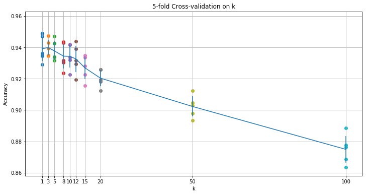

```python
# Plot accuracies per k
_, ax = plt.subplots(figsize=(12,6), subplot_kw=dict(xticks=k_choices))
for i, k in enumerate(k_choices):
    curr_accuracies = accuracies[i]
    ax.scatter([k] * len(curr_accuracies), curr_accuracies)

accuracies_mean = np.array([np.mean(accs) for accs in accuracies])
accuracies_std = np.array([np.std(accs) for accs in accuracies])
ax.errorbar(k_choices, accuracies_mean, yerr=accuracies_std)
ax.set_title(f'{num_folds}-fold Cross-validation on k')
ax.set_xlabel('k')
ax.set_ylabel('Accuracy')
ax.grid()

print('best_k =', best_k)
```

Now that we found our `best_k`, we can train the model with that value of `k` on the full training set and evaluate the accuracy on the test set:

```python
knn_classifier = hw1knn.KNNClassifier(k=best_k)
knn_classifier.train(dl_train)
y_pred = knn_classifier.predict(x_test)

# Calculate accuracy
accuracy_best_k = hw1knn.accuracy(y_test, y_pred)
print(f'Accuracy: {accuracy_best_k*100:.2f}%')

test.assertGreater(accuracy_best_k, accuracy)
```

```
Accuracy: 91.90%
```

### Questions

**TODO** Answer the following questions. Write your answers in the appropriate variables in the module `hw1/answers.py`.

```python
from cs236605.answers import display_answer
import hw1.answers
```

#### Question 1

Does increasing `k` lead to improved generalization for unseen data? Why or why not? Up to what point? Think about the extremal values of `k`.

```python
display_answer(hw1.answers.part2_q1)
```

we can see that for a realy small k, eg. 1 ,we will overffit because we will predict blindly according to the training examples. if k is very large we will consider too much data points and that can introduce noise to the prediction in the exterme our prediction can be seen as a majority vote accros the entire dataset. the sweet spot is somewhere in the middle where we consider a reasonable amount of close examples to determine a datapoint classification

## Part 3: Multiclass linear classification

$ \newcommand{\mat}[1]{\boldsymbol {#1}} \newcommand{\mattr}[1]{\boldsymbol {#1}^\top} \newcommand{\matinv}[1]{\boldsymbol {#1}^{-1}} \newcommand{\vec}[1]{\boldsymbol {#1}} \newcommand{\vectr}[1]{\boldsymbol {#1}^\top} \newcommand{\diag}{\mathop{\mathrm {diag}}} \newcommand{\set}[1]{\mathbb {#1}} \newcommand{\norm}[1]{\left\lVert#1\right\rVert} \newcommand{\pderiv}[2]{\frac{\partial {#1}}{\partial {#2}}} $

In this part we'll learn about loss functions and how to optimize them with gradient descent. We'll then use this knowledge to train a very simple model: a linear SVM.

```python
import torch
import torchvision
import numpy as np
import matplotlib.pyplot as plt
import unittest

%matplotlib inline
%load_ext autoreload
%autoreload 2

plt.rcParams.update({'font.size': 12})
torch.random.manual_seed(1904)
test = unittest.TestCase()
```

### Linear Classification

In multi-class linear classification we have $C$ classes which we assume our samples may belong to. We apply a linear function to a sample $x \in \set{R}^{D}$ and obtain a score $s_j$ which represents how well $x$ fits the class $1\leq j\leq C$ according to our model: $$ s_j = \vectr{w_j} x + b_j. $$

Note that we have a different set of model parameters (weights) $\vec{w_j},~b_j$ for each class, so a total of $C\cdot(D+1)$ parameters.

To classify a sample, we simply calculate the score for each class and choose the class with the highest score as our prediction.

One interpretation of the weights $\vec{w_j},~b_j$ is that they represent the parameters of an $N$-dimensional hyperplane. Under this interpretation the class score $s_j$ of a sample is proportional to the distance of that sample from the hyperplane representing the $j$-th class. Note that this score can be positive or negative (depending on which side of the hyperplane the sample is). Such a classifier therefore splits the sample space into regions where the farther a sample is from the positive side of a hyperplane for class $j$, the higher $s_j$, so the more likely it belongs to class $j$.

[figure not shown]

#### Implementation

In the context of supervised learning of a linear classifier model, we map a dataset (or batch from a dataset) of $N$ samples (for example, images flattened to vectors of length $D$) to a score for one of each of $C$ possible classes using the linear function above.

To make the implementation efficient, we'll represent the mapping with a single matrix multiplication, employing the "Bias trick": Instead of both $\vec{w_j}$ and $b_j$ per class, we'll put the bias term at the end of the weight vector and add a term $1$ at the end of each sample.

The class scores for each sample are then given by:

$$ \mat{S} = \mat{X} \mat{W} $$

Where here (and in the code examples you'll work with),

- $\mat{X}$ is a matrix of shape $N\times (D+1)$ containing $N$ samples in it's rows;
- $\mat{W}$ is of shape $(D+1)\times C$ and contains the learnable classifier parameters (weights and bias);
- $\mat{S}$ is therefore a $N\times C$ matrix of the class scores of each sample.

Notes:

1. In the following discussions we'll use the notation $\vec{x_i}$ to denote the $i$-th training sample (row $i$ in $\mat{X}$) and $\vec{w_j}$ to denote the weights and bias for class $j$ (column $j$ in $\mat{W}$). However, when writing explicit vectors we treat them all as columns, so e.g. $\vectr{w_j}\vec{x_i}$ is an inner product.
2. The reason we put the samples in the rows of $\mat{X}$ and not columns (as is the convention in some texts) is because that's the convention in the pytorch library: the batch dimension is always the first one. This has many implementation advantages.

**TODO** Implement a transform that performs the "bias trick" on a tensor in the module `hw1/transforms.py`. The following code will use your transform to load a subset of the [MNIST](http://yann.lecun.com/exdb/mnist/) dataset for us to work with.

```python
# Prepare data for Linear Classifier
import torchvision.transforms as tvtf
import hw1.datasets as hw1datasets
import hw1.dataloaders as hw1dataloaders
import hw1.transforms as hw1tf
import torch

# Define the transforms that should be applied to each image in the dataset before returning it
tf_ds = tvtf.Compose([
    tvtf.ToTensor(), # Convert PIL image to pytorch Tensor
    tvtf.Normalize(
        # Normalize each chanel with precomputed mean and std of the train set
        mean=(0.49139968, 0.48215841, 0.44653091),
        std=(0.24703223,  0.24348513, 0.26158784)),
    hw1tf.TensorView(-1), # Reshape to 1D Tensor
    hw1tf.BiasTrick(), # Apply the bias trick (add bias dimension to data)
])

# Define how much data to load
num_train = 10000
num_test = 1000
batch_size = 1000

# Training dataset
ds_train = hw1datasets.SubsetDataset(
    torchvision.datasets.MNIST(root='./data/mnist/', download=True, train=True, transform=tf_ds),
    num_train)

# Create training & validation sets
dl_train, dl_valid = hw1dataloaders.create_train_validation_loaders(
    ds_train, validation_ratio=0.2, batch_size=batch_size
)

# Test dataset & loader
ds_test = hw1datasets.SubsetDataset(
    torchvision.datasets.MNIST(root='./data/mnist/', download=True, train=False, transform=tf_ds),
    num_test)
dl_test = torch.utils.data.DataLoader(ds_test, batch_size)

x0, y0 = ds_train[0]
n_features = torch.numel(x0)
n_classes = 10

# # Make sure samples have bias term added
test.assertEqual(n_features, 28*28*1+1, "Incorrect sample dimension")
```

**TODO** Complete the implementation of the `__init()__`, `predict()` and `evaluate_accuracy()` functions in the `LinearClassifier` class located in the `hw1/linear_classifier.py` module.

```python
import hw1.linear_classifier as hw1linear

# Create a classifier
lin_cls = hw1linear.LinearClassifier(n_features, n_classes)

# Evaluate accuracy on test set
mean_acc = 0
for (x,y) in dl_test:
    y_pred, _ = lin_cls.predict(x)
    mean_acc += lin_cls.evaluate_accuracy(y, y_pred)
mean_acc /= len(dl_test)

print(f"Accuracy: {mean_acc:.1f}%")
```

```
Accuracy: 12.2%
```

You should get an accuracy of around 10%, corresponding to a random guess of one of ten classes. You can run the above code block multiple times to sample different initial weights and get slightly different results.

### Loss Functions

We have seen that a linear model computes the class scores for each sample using a linear mapping as a score function. However in order to train the model, we need to define some measure of how well we've classified our samples compared to their ground truth labels. This measure is known as a **loss function**, and it's selection is crucial in determining the model that will result from training. A loss function produces lower values the better the classification is.

#### Multiclass SVM loss function

A very common linear model for classification is the Support Vector Machine. An SVM attempts to find separating hyperplanes that have the property of creating a maximal margin to the training samples, i.e. hyperplanes that are as far as possible from the closest training samples. For example, in the following image we see a simple case with two classes of samples that have only two features. The data is linearly separable and it's easy to see there are infinite possible hyperplanes (in this case lines) that separate the data perfectly. In this case The SVM model finds the optimal hyperplane, which is the one with the maximal margin. The data points closest to the separating hyperplane are called the Support Vectors (it can be shown that only they determine the hyperplane). We can see that the width of the margin is $\frac{2}{\norm{\vec{w}}}$. In this simple case since the data is linearly separable, there exists a solution where no sample fall within the margin. If the data is not linearly separable, we need to allow samples to enter the margin (with a cost). This is known as a soft-margin SVM.

[figure not shown]

There are many ways to train an SVM model. Classically, the problem is stated as constrained optimization and solved with quadratic optimization techniques. In this exercise, we'll instead work directly with the uncontrained SVM loss function, calculate it's gradient analytically, and then minimize it with gradient descent. As we'll see in the rest of the course, this technique will be a major component when we train deep neural networks.

The in-sample loss function for a multiclass soft-margin SVM can be stated as follows:

$$ L(\mat{W}) = \frac{1}{N} \sum_{i=1}^{N} L_{i}(\mat{W}) + \frac{\lambda}{2} \norm{\mat{W}}^2 $$

Where the first term is the mean pointwise data-dependent loss $L_{i}$, given by the [hinge loss](https://en.wikipedia.org/wiki/Hinge_loss) formula,

$$ L_{i}(\mat{W}) = \sum_{j \neq y_i} \max\left(0, \Delta+ \vectr{w_j} \vec{x_i} - \vectr{w_{y_i}} \vec{x_i}\right), $$

and the second term is a regularization loss which depends only on model parameters. Note that the hinge loss term sums over the *wrong* class prediction scores for each sample. This can be understood as attempting to make sure that the score for the correct class is higher than the other classes by at least some margin $\Delta > 0$, otherwise a loss is incurred. Since this is a soft-margin SVM we allow samples to fall within the margin but it accumulates loss. The regularization term penalizes large weight magnitudes to prevent ambiguous solutions since if e.g. $\mat{W^*}$ is a weight matrix that perfectly separates the data, so is $\alpha\mat{W^*}$ for any scalar $\alpha \geq 1$.

Fitting an SVM model then amounts to finding the weight matrix $\mat{W}$ which minimizes $L(\mat{W})$. Note that we're writing the loss as a function of $\mat{W}$ to emphasize that we wish to minimize it's value on the given data by with respect to the weights $\mat{W}$, even though it obviously depends also on the specific dataset, $\left\{ \vec{x_i}, y_i \right\}_{i=1}^{N}$.

#### Implementation

**TODO** Implement the SVM hinge loss function in the module `hw1/losses.py`, within the `SVMHingeLoss` class. Implement just the `loss()` function. For now you can ignore the part about saving tensors for the gradient calculation. Run the following to test.

```python
import cs236605.dataloader_utils as dl_utils
from hw1.losses import SVMHingeLoss

# Create a hinge-loss function
loss_fn = SVMHingeLoss(delta=1.)

# Classify all samples in the test set (because it doesn't depend on initialization)
x, y = dl_utils.flatten(dl_test)
y_pred, x_scores = lin_cls.predict(x)

# # Compute loss
loss = loss_fn(x, y, x_scores, y_pred)
print(loss)
# Compare to pre-computed expected value as a test
expected_loss = 8.9579
print("loss =", loss.item())
print('diff =', abs(loss.item()-expected_loss))
test.assertAlmostEqual(loss.item(), expected_loss, delta=1e-1)
```

```
tensor(8.9580)
loss = 8.95799732208252
diff = 9.732208251911345e-05
```

### Optimizing a Loss Function with Gradient Descent

In this section we'll implement a simple gradient descent optimizer for the loss function we've implemented above. As you may recall from the lectures, the basic gradient-based optimization scheme is as follows:

1. Start with initial model weights $\mat{W_0}$ initialized randomly.
2. For $k=1,2,\dots,K$:
   1. Select a step size $\eta_k$.
   2. Compute the gradient of the loss w.r.t. $\mat{W}$ and evaluate at the current weights: $\nabla_{\mat{W}} L(\mat{W_{k-1}})$.
   3. Update: $$ \mat{W_k} = \mat{W_{k-1}} - \eta_k \nabla_{\mat{W}} L(\mat{W_{k-1}}) $$
   4. Stop if minimum reached or validation-set loss is low enough.

The crucial component here is the gradient calculation. In this exercise we'll analytically derive the gradient of the loss and then implement it in code.

An important detail to note is that while $L(\mat{W})$ is scalar-valued, it's a function of all the elements of the matrix $\mat{W}$. Therefore it's gradient w.r.t. $\mat{W}$ is also a matrix of the same shape as $\mat{W}$:

$$ \nabla_{\mat{W}} L = \begin{bmatrix} \frac{\partial L}{\partial W_{1,1}} & & \cdots & \frac{\partial L}{\partial W_{1,C}} \\ \frac{\partial L}{\partial W_{2,1}} & \ddots & \\ \vdots & & \ddots & \\ \frac{\partial L}{\partial W_{D,1}} & \cdots & & \frac{\partial L}{\partial W_{D,C}} \\ \end{bmatrix} = \begin{bmatrix} \vert & & \vert \\ \frac{\partial L}{\partial\vec{w_1}} & \cdots & \frac{\partial L}{\partial\vec{w_C}}\\ \vert & & \vert \\ \end{bmatrix} \in \set{R}^{(D+1)\times C}. $$

For our gradient descent update-step we'll need to create such a matrix of derivatives and evaluate it at the current value of the weight matrix.

#### SVM loss gradient

The first thing we need to do is formulate an expression for the gradient of the loss function defined above. Since the expression for the loss depends on the columns of $\mat{W}$, we'll derive an expression for the gradient of $L(\mat{W})$ w.r.t. each $\vec{w_j}$:

$$ \pderiv{L}{\vec{w_j}}(\mat{W}) = \frac{1}{N} \sum_{i=1}^{N} \pderiv{L_{i}}{\vec{w_j}}(\mat{W}) + \lambda \mat{W}. $$

To compute the gradient of the pointwise loss, let's define the **margin-loss** of sample $i$ for class $j$ as follows: $m_{i,j} = \Delta + \vectr{w_j}\vec{x_i} - \vectr{w_{y_i}}\vec{x_i}$. We can then write the pointwise loss and it's gradient in terms of $m_{i,j}$. We'll separate the case of $j=y_i$ (i.e. the gradient for the correct class):

$$ \begin{align} \pderiv{L_i}{\vec{w_j}} & = \begin{cases} \vec{x_i}, & m_{i,j}>0 \\ 0, & \mathrm{else} \\ \end{cases} ,~j \neq y_i \\ \\ \pderiv{L_i}{\vec{w_{y_i}}} & = -\vec{x_i} \sum_{j\neq y_i} \mathbb{1}\left( m_{i,j} > 0 \right) \end{align} $$

Where $\mathbb{1}(\cdot)$ is an indicator function that takes the value $1$ if it's argument is a true statement, else it takes $0$.

Note: the hinge-loss function is not strictly speaking differentiable due to the $\max$ operator. However, in practice it's not a major concern. Given that we know what argument the $\max$ "cooses", we can differentiate each one of them separately. This is known as a sub-gradient. In the above, when $m_{i,j} \leq 0$ we know the gradient will simply be zero.

**TODO** Based on the above, implement the gradient of the loss function in the module `hw1/losses.py`, within the `SVMHingeLoss` class. Implement the `grad()` function and complete what's missing in the `loss()` function. Make sure you understand the above gradient derivation before attempting to implement it.

Note: you'll be implementing the first term in the above equation for $\pderiv{L}{\vec{w_j}}(\mat{W})$. We'll add the regularization term later.

```python
from hw1.losses import SVMHingeLoss

# Create a hinge-loss function
loss_fn = SVMHingeLoss(delta=1)

# Compute loss and gradient
loss = loss_fn(x, y, x_scores, y_pred)
grad = loss_fn.grad()

# Test the gradient with a pre-computed expected value
expected_grad = torch.load('tests/assets/part3_expected_grad.pt')
diff = torch.norm(grad - expected_grad)
print('diff =', diff.item())
test.assertAlmostEqual(diff, 0, delta=1e-1)
```

```
diff = 0.0
```

### Training the model with SGD

Now that we have implemented our loss function and it's gradient, we can finally train our model. Generally, solving a machine-learning problem requires defining the following components:

- A model: architecture (type of model) consisting of hyperparameters (e.g. number of hidden layers, number of classes, etc) which are set in advance and trainable parameters which we want to fit to data.
- A loss function (sometimes denoted as a criterion): evaluates the model output on some data compared to ground truth.
- An optimization scheme: specifies how the model should be updated to improve the loss. May also have hyperparameters.
- A dataset: What to fit the model to. Usually the available data is split into training, validation and test sets.

Implementation notes:

- You'll find that when implementing your solutions it's wise to keep the above components separate as to be able to change each one of them independently from the other.
- In this exercise we'll have separated the loss and dataset, however for simplicity we'll implement the model and optimizer together.
- As you'll see further on, `PyTorch` provides very effective mechanisms to implement all of these components in a decoupled manner.
- Note that our loss implementation didn't include regularization. We'll add this during the training phase using the `weight_decay` parameter. The reason is that we prefer that the part of the loss which only depends on the model parameters be part of the optimizer, not the loss function (though both ways are possible). You'll see this pattern later on when you use `PyTorch`'s optimizers in the `torch.optim` package.
- In practice we use batches of samples from the training set when training the model, because usually the training set can't fit into memory. Using gradients computed on batches of data at a time is known as mini-batch stochastic gradient descent (SGD).

**TODO** Implement the model training loop in the `LinearClassifier`'s `train()` function. Use mini-batch SGD for the weight update rule.

Note: You should play with the hyperparameters to get a feel for what they do to the loss and accuracy graphs.

```
Training...............................
Test-set accuracy before training: 9.4%
Test-set accuracy after training: 87.2%
```

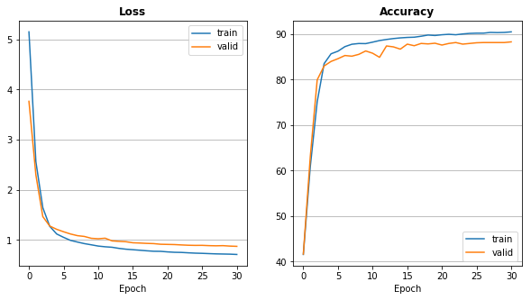

```python
lin_cls = hw1linear.LinearClassifier(n_features, n_classes)

# Evaluate on the test set
x_test, y_test = dl_utils.flatten(dl_test)
y_test_pred , _= lin_cls.predict(x_test)
test_acc_before = lin_cls.evaluate_accuracy(y_test, y_test_pred)

# Train the model
svm_loss_fn = SVMHingeLoss()
train_res, valid_res = lin_cls.train(dl_train, dl_valid, svm_loss_fn,
                                    learn_rate=1e-3, weight_decay=0.5,
                                    max_epochs=31)

# Re-evaluate on the test set
y_test_pred , _= lin_cls.predict(x_test)
test_acc_after = lin_cls.evaluate_accuracy(y_test, y_test_pred)

# Plot loss and accuracy
fig, axes = plt.subplots(nrows=1, ncols=2, figsize=(10,5))
for i, loss_acc in enumerate(('loss', 'accuracy')):
    axes[i].plot(getattr(train_res, loss_acc))
    axes[i].plot(getattr(valid_res, loss_acc))
    axes[i].set_title(loss_acc.capitalize(), fontweight='bold')
    axes[i].set_xlabel('Epoch')
    axes[i].legend(('train', 'valid'))
    axes[i].grid(which='both', axis='y')

# Check test set accuracy
print(f'Test-set accuracy before training: {test_acc_before:.1f}%')
print(f'Test-set accuracy after training: {test_acc_after:.1f}%')
test.assertGreaterEqual(test_acc_after, 80.0)
```

Even though this is a very naïve model, you should get at least 80% test set accuracy if you implemented training correctly. You can try to change the hyperparameters and see whether you get better results. Generally this should be done with cross-validation.

#### Visualization

One way to unnderstand what models learn is to try to visualize their learned parameters. There can be many ways to do this. Let's try a very simple one, which is to reshape them into images of the input size and see what they look like.

**TODO** Implement the `weights_as_images()` function in the `LinearClassifier` class.

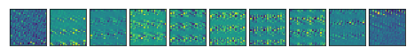

```python
import cs236605.plot as plot

w_images = lin_cls.weights_as_images(img_shape=(1,28,28))
fig, axes = plot.tensors_as_images(list(w_images))
```

Additionally, we can better understand the model by plotting some samples and looking at wrong predictions. Run the following block to visualize some test-set examples and the model's predictions for them.

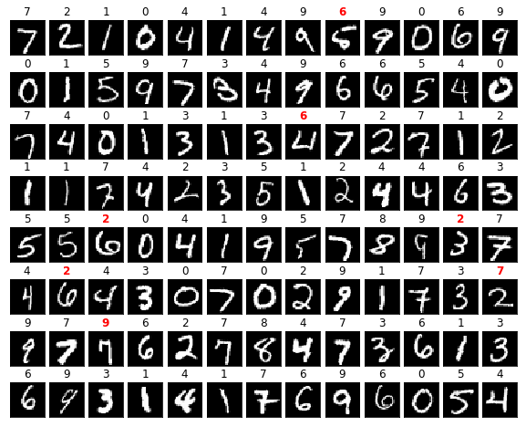

```python
# Plot some images from the test set and their predictions
n_plot = 104
x_test, y_test = next(iter(dl_test))
x_test = x_test[0:n_plot]
y_test = y_test[0:n_plot]
y_test_pred, _ = lin_cls.predict(x_test)
x_test_img = torch.reshape(x_test[:, :-1], (n_plot, 1, 28, 28))

fig, axes = plot.tensors_as_images(list(x_test_img), titles=y_test_pred.numpy(),
                                   nrows=8, hspace=0.5, figsize=(10,8), cmap='gray')

# Highlight the wrong predictions
wrong_pred = y_test_pred != y_test
wrong_pred_axes = axes.ravel()[wrong_pred.numpy().astype(np.bool)]
for ax in wrong_pred_axes:
    ax.title.set_color('red')
    ax.title.set_fontweight('bold')
```

### Automatic differentiation

In the simple linear model we worked with, the gradient was fairly straightforward to derive analytically and implement. However for complex models such as deep neural networks with many layers and non-linear operations between them this is not the case. Additionally, the gradient must be re-derived any time either the model architecture or the loss function changes. These things make it infeasible in practice to perform deep-learning research using this manual method of gradient derivation. Therefore, all deep-learning frameworks provide a mechanism of [automatic differentiation](https://en.wikipedia.org/wiki/Automatic_differentiation), to prevent the user from needing to manually derive the gradients of loss functions.

`PyTorch` provides this functionality in a package named `torch.autograd` which we will use further on in the next exercises. For now, here's an example showing that autograd can compute the gradient of the loss function you've implemented.

```python
# Create a new classifier
lin_cls = hw1linear.LinearClassifier(n_features, n_classes)
x, y = dl_utils.flatten(dl_test)

# Specify we want the gradient to be saved for the weights tensor
lin_cls.weights.requires_grad = True

# Forward pass using the weights tensor, operations will be tracked
y_pred, x_scores = lin_cls.predict(x)

# Compute loss and analytic gradient
loss_fn = SVMHingeLoss(delta=1)
loss = loss_fn(x, y, x_scores, y_pred)
grad = loss_fn.grad()

# Compute gradient with autograd
loss.backward()
autograd = lin_cls.weights.grad

diff = torch.norm(grad - autograd).item()
print('loss =', loss.item())
print('grad =\n', grad)
print('autograd =\n', autograd)
print('diff =', diff)
test.assertLess(diff, 1e-3, "Gradient diff was too large")
```

```
loss = 8.98302173614502
grad =
 tensor([[-0.2984,  0.5172,  0.3183,  ..., -0.0199, -0.2188, -0.1194],
        [-0.2984,  0.5172,  0.3183,  ..., -0.0199, -0.2188, -0.1194],
        [-0.2984,  0.5172,  0.3183,  ..., -0.0199, -0.2188, -0.1194],
        ...,
        [-0.2984,  0.5172,  0.3183,  ..., -0.0199, -0.2188, -0.1194],
        [-0.2984,  0.5172,  0.3183,  ..., -0.0199, -0.2188, -0.1194],
        [ 0.1500, -0.2600, -0.1600,  ...,  0.0100,  0.1100,  0.0600]])
autograd =
 tensor([[-0.2984,  0.5172,  0.3183,  ..., -0.0199, -0.2188, -0.1194],
        [-0.2984,  0.5172,  0.3183,  ..., -0.0199, -0.2188, -0.1194],
        [-0.2984,  0.5172,  0.3183,  ..., -0.0199, -0.2188, -0.1194],
        ...,
        [-0.2984,  0.5172,  0.3183,  ..., -0.0199, -0.2188, -0.1194],
        [-0.2984,  0.5172,  0.3183,  ..., -0.0199, -0.2188, -0.1194],
        [ 0.1500, -0.2600, -0.1600,  ...,  0.0100,  0.1100,  0.0600]])
diff = 4.7249144699890167e-05
```

### Questions

**TODO** Answer the following questions. Write your answers in the appropriate variables in the module `hw1/answers.py`.

```python
from cs236605.answers import display_answer
import hw1.answers
```

#### Question 1

Explain why the selection of $\Delta > 0$ is arbitrary for the SVM loss $L(\mat{W})$ as it is defined above.

```python
display_answer(hw1.answers.part3_q1)
```

the hinge loss assures that the score of the correct label will larger by at least delta from all othe label. because we return the label with the heighest score it does not matter which value of delta we choose as long as its positive.

#### Question 2

Given the images in the visualization section above,

1. How do you interpret what the linear model is actually learning? Can you explain some of the classification errors based on it?
2. How is this interpretation similar or different from KNN?

```python
display_answer(hw1.answers.part3_q2)
```

1.the linear classifier is trying to find a linear seperator(weights) that seperates between the different classes as good as possible, trying to come close as much as possible to one that seperates them with a distance of delta.

1. KNN doesnt seperate between the classes in a linear way he just classifies the exampels according to arbitrery partitions of the domain.

#### Question 3

1. Based on the graph of the training set loss, would you say that the learning rate is:
   - Too low
   - Good
   - Too High

   Explain your answer by describing what the loss graph would look like in the other two cases when training for the same number of epochs.
2. Based on the graph of the training and test set accuracy, would you say that the model is:
   - Slightly overfitted to the training set
   - Highly overfitted to the training set
   - Slightly underfitted to the training set
   - Highly underfitted to the training set

   and why?

```python
display_answer(hw1.answers.part3_q3)
```

we would say the learning rate is not too high because if it was then we would have seen spikes in the loss and accuracy metrics and slower convergence due to irratic changes in the model parameters. also it's not too low because we see that the curve is steep and 4 epochs is enough for reasonable loss and accuracy values.

in regard to the over/under fitting of the model we would say that the model is slightly overffited on the training set because after epoch 5 we can see the margin between the graphs(before they were almont identical) thus we assume that we start to generalize less on the validtaion set and hinder the improvement of the validation loss and accuracy

## Part 4: Linear Regression

$ \newcommand{\mat}[1]{\boldsymbol {#1}} \newcommand{\mattr}[1]{\boldsymbol {#1}^\top} \newcommand{\matinv}[1]{\boldsymbol {#1}^{-1}} \newcommand{\vec}[1]{\boldsymbol {#1}} \newcommand{\vectr}[1]{\boldsymbol {#1}^\top} \newcommand{\diag}{\mathop{\mathrm {diag}}} \newcommand{\set}[1]{\mathbb {#1}} \newcommand{\norm}[1]{\left\lVert#1\right\rVert} \newcommand{\pderiv}[2]{\frac{\partial {#1}}{\partial {#2}}} $

In this part we'll perform the classic machine learning task of linear regression. We'll do some simple data exploration, and implement our solution using some very widely used python libraries ([`numpy`](https://docs.scipy.org/doc/numpy-1.15.1/reference/), [`scikit-learn`](http://scikit-learn.org/stable/documentation.html) and [`pandas`](http://pandas.pydata.org/pandas-docs/stable/)) in order to gain some basic experience with them. We'll explore the generalization capacity of the model and perform cross validation.

```python
import numpy as np
import pandas as pd
import sklearn
import matplotlib.pyplot as plt
import unittest


%matplotlib inline
%load_ext autoreload
%autoreload 2

plt.rcParams.update({'font.size': 14})
np.random.seed(42)
test = unittest.TestCase()
```

### Dataset exploration

We'll be working with the Boston housing dataset. This is a famous dataset for benchmarking regression algorithms.

The dataset contains 506 samples of median house values in Boston, each with 13 associated house and neighborhood attributes (i.e. features). (see [here](http://scikit-learn.org/stable/datasets/index.html#boston-dataset) for their meaning). The 13 features of each house are our independent variables, and we're trying to predict the value of `MEDV`, the median house price (in units of $1000).

Run the following block to load the data. Since this dataset is very small, we can load it directly into memory and forgo any lazy-loading mechanisms.

```python
import sklearn.datasets

# Load data we'll work with - Boston housing dataset
# We'll use sklearn's built-in data
ds_boston = sklearn.datasets.load_boston()
feature_names = ds_boston.feature_names
n_features = len(feature_names)
x, y = ds_boston.data, ds_boston.target
n_samples = len(y)
print(f'Loaded {n_samples} samples')

# Load into a pandas dataframe and show some samples
df_boston = pd.DataFrame(data=x, columns=ds_boston.feature_names)
df_boston = df_boston.assign(MEDV=y)
df_boston.head(10).style.background_gradient(subset=['MEDV'], high=1.)
```

```
Loaded 506 samples
```

|  | CRIM | ZN | INDUS | CHAS | NOX | RM | AGE | DIS | RAD | TAX | PTRATIO | B | LSTAT | MEDV |
| --- | --- | --- | --- | --- | --- | --- | --- | --- | --- | --- | --- | --- | --- | --- |
| 0 | 0.00632 | 18 | 2.31 | 0 | 0.538 | 6.575 | 65.2 | 4.09 | 1 | 296 | 15.3 | 396.9 | 4.98 | 24 |
| 1 | 0.02731 | 0 | 7.07 | 0 | 0.469 | 6.421 | 78.9 | 4.9671 | 2 | 242 | 17.8 | 396.9 | 9.14 | 21.6 |
| 2 | 0.02729 | 0 | 7.07 | 0 | 0.469 | 7.185 | 61.1 | 4.9671 | 2 | 242 | 17.8 | 392.83 | 4.03 | 34.7 |
| 3 | 0.03237 | 0 | 2.18 | 0 | 0.458 | 6.998 | 45.8 | 6.0622 | 3 | 222 | 18.7 | 394.63 | 2.94 | 33.4 |
| 4 | 0.06905 | 0 | 2.18 | 0 | 0.458 | 7.147 | 54.2 | 6.0622 | 3 | 222 | 18.7 | 396.9 | 5.33 | 36.2 |
| 5 | 0.02985 | 0 | 2.18 | 0 | 0.458 | 6.43 | 58.7 | 6.0622 | 3 | 222 | 18.7 | 394.12 | 5.21 | 28.7 |
| 6 | 0.08829 | 12.5 | 7.87 | 0 | 0.524 | 6.012 | 66.6 | 5.5605 | 5 | 311 | 15.2 | 395.6 | 12.43 | 22.9 |
| 7 | 0.14455 | 12.5 | 7.87 | 0 | 0.524 | 6.172 | 96.1 | 5.9505 | 5 | 311 | 15.2 | 396.9 | 19.15 | 27.1 |
| 8 | 0.21124 | 12.5 | 7.87 | 0 | 0.524 | 5.631 | 100 | 6.0821 | 5 | 311 | 15.2 | 386.63 | 29.93 | 16.5 |
| 9 | 0.17004 | 12.5 | 7.87 | 0 | 0.524 | 6.004 | 85.9 | 6.5921 | 5 | 311 | 15.2 | 386.71 | 17.1 | 18.9 |

Let's explore the data a bit by plotting a scatter matrix of every variable as a function of every other and a histogram for each.

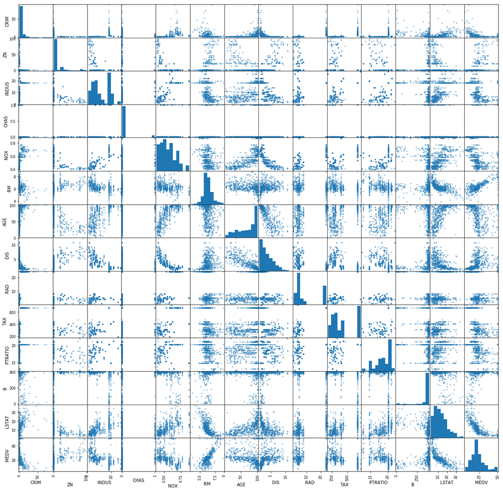

```python
pd.plotting.scatter_matrix(df_boston, figsize=(20,20));
```

The above chart shows us (among other things) how our target variable `MEDV` behaves as a function of the features (bottom row). By looking at it, can you guess which relationships might be good candidates for a linear model?

Let's use a simple method for deciding which features to use for our linear model: the [correlation coefficient](https://en.wikipedia.org/wiki/Pearson_correlation_coefficient), defined as

$$ \rho_{\vec{x}\vec{y}} = \frac{\sigma_{\vec{x}\vec{y}}}{\sigma_{\vec{x}} \sigma_{\vec{y}}} = \frac {\sum_{i=1}^{N} (x_i - \mu_\vec{x}) (y_i - \mu_\vec{y}) } {\sqrt{\sum_{i=1}^{N} (x_i - \mu_\vec{x})^2} \cdot \sqrt{\sum_{i=1}^{N} (y_i - \mu_\vec{y})^2}} $$

Where $\vec{x}, \vec{y}$ are $N$ samples of two variables and $\mu, \sigma$ refer to **sample** means and (co-)variances respectively. The value of $\rho$ is $\pm 1$ for perfect positive or negative linear relationships ($y=ax+b$), and somewhere in between when it's not perfect. Note that this coefficient is rather limited: even when $\rho=0$, the variables may be highly dependent, just not in a linear fashion.

Let's implement this method to find out which features we should include in our initial linear model.

**TODO** Implement the `top_correlated_features()` function in the `hw1/linear_regression.py` module.

```python
import hw1.linear_regression as hw1linreg

n_top_features = 5
top_feature_names, top_corr = hw1linreg.top_correlated_features(df_boston, 'MEDV', n_top_features)
print('Top features: ', top_feature_names)
print('Top features correlations: ', top_corr)

# Tests
test.assertEqual(len(top_feature_names), n_top_features)
test.assertEqual(len(top_corr), n_top_features)
test.assertAlmostEqual(np.sum(np.abs(top_corr)), 2.893, delta=1e-3) # compare to precomputed value for n=5
```

```
Top features:  ['LSTAT', 'RM', 'PTRATIO', 'INDUS', 'TAX']
Top features correlations:  [0.7376627261740143, 0.6953599470715389, 0.507786685537561, 0.483725160028373, 0.46853593356776646]
```

### Linear Regression Model

Arguably the simplest machine learning model is linear regression. We are given a dataset $\left\{\vec{x}^{(i)}, y^{(i)}\right\}_{i=1}^{N}$ where $\vec{x}^{(i)} \in \set{R}^D$ is a $D$-dimensional feature vector and $y^{(i)}\in\set{R}$ is a continuous quantity assumed to be the output of some unknown function, i.e. $y^{(i)} = f(\vec{x}^{(i)})$.

Our goal will be to fit a linear transformation, parametrized by weights vector and bias term $\vec{w}, b$, such that given a sample $\vec{x}$ our prediction is

$$ \hat{y} = \vectr{w}\vec{x} + b. $$

We'll judge the performance of the model using the ordinary least-squares sense, i.e. with a loss function of given by the mean-squared error (MSE) with the addition of an L2-regularization term: $$ L(\vec{w}) = \frac{1}{2N} \sum_{i=1}^{N} \left( y^{(i)} - \hat{y}^{(i)} \right)^2 + \frac{\lambda}{2}\norm{\vec{w}}^2_2 = \frac{1}{2N} \sum_{i=1}^{N} \left( y^{(i)} - \vectr{w}\vec{x}^{(i)} - b \right)^2 + \frac{\lambda}{2}\norm{\vec{w}}^2_2. $$

Minimizing the above $L(\vec{w})$ is a simple convex optimization problem with a closed-form solution. Of course, this can also be solved using iterative descent methods which are necessary when the data is too large to fit in memory.

As a warm up, let's implement the bias trick (this time as a `sklearn` transformation) so that our linear regression model will operate on data with an added bias term.

**TODO** Implement the class `BiasTrickTransformer` in the `hw1/linear_regression.py` module.

```python
# Test BiasTrickTransformer
bias_tf = hw1linreg.BiasTrickTransformer()

xt1 = np.random.randint(10, 20, size=(5,2))
xt2 = np.random.randn(10, 1)
for xt in (xt2, xt1):
    xb = bias_tf.fit_transform(xt)
    test.assertEqual(xb.ndim, 2)
    test.assertTrue(np.all(xb[:,0] == 1))
    test.assertTrue(np.all(xb[:, 1:] == xt))

print(xb)
```

```
[[ 1. 16. 13.]
 [ 1. 17. 14.]
 [ 1. 16. 19.]
 [ 1. 12. 16.]
 [ 1. 17. 14.]]
```

Lets now define a function to assess the accuracy of our models prediction (loss and score). We'll use the MSE loss as above and [$R^2$](https://en.wikipedia.org/wiki/Coefficient_of_determination) as a score.

```python
def evaluate_accuracy(y: np.ndarray, y_pred: np.ndarray):
    """
    Calculates mean squared error (MSE) and coefficient of determination (R-squared).
    :param y: Target values.
    :param y_pred: Predicted values.
    :return: A tuple containing the MSE and R-squared values.
    """
    mse = np.mean((y - y_pred) ** 2)
    rsq = 1 - mse / np.var(y)
    return mse.item(), rsq.item()
```

Now we can implement our model.

**TODO** Based on the above equations, implement the `predict()` and `fit()` functions in the `LinearRegressor` class within the module `linear_regression.py`. You'll need to first derive the closed-form solution for the optimal $\vec{w}$ based on the loss. Run the code block below to fit your model to each of the 5 top features you selected (one at a time).

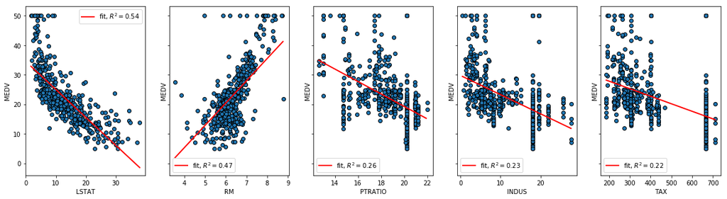

```python
import sklearn.pipeline

fig, ax = plt.subplots(nrows=1, ncols=n_top_features, sharey=True, figsize=(20,5))
actual_mse = []

# Create our model as a pipline: First the bias trick is applied, then the regressor
model = sklearn.pipeline.make_pipeline(
    hw1linreg.BiasTrickTransformer(),
    hw1linreg.LinearRegressor(),
)

# Fit a single feature at a time
for i, feature_name in enumerate(top_feature_names):
    xf = df_boston[feature_name].values.reshape(-1, 1)
    y_pred = model.fit_predict(xf, y)
    mse, rsq = evaluate_accuracy(y, y_pred)

    x_line = np.arange(xf.min(), xf.max(), 0.1, dtype=np.float).reshape(-1, 1)
    y_line = model.predict(x_line)

    # Plot
    ax[i].scatter(xf, y, marker='o', edgecolor='black')
    ax[i].plot(x_line, y_line, color='red', lw=2, label=f'fit, $R^2={rsq:.2f}$')
    ax[i].set_ylabel('MEDV')
    ax[i].set_xlabel(feature_name)
    ax[i].legend()

    actual_mse.append(mse)

# Test regressor implementation
expected_mse = [38.483, 44.762, 62.661, 64.666, 65.887]
for i in range(len(expected_mse)):
    test.assertAlmostEqual(expected_mse[i], actual_mse[i], delta=1e-1)
```

As you can see, the results are not great. We can't reliably predict the target variable based on just one of these. Now let's fit a model based on the combined top-5 features. Since it's difficult to visualize high-dimensional hyperplanes, instead of plotting the data and fitted hyperplane, we'll create a **residuals** plot. This is the plot of the error, or residual $e^{(i)} = y^{(i)} - \hat{y}^{(i)}$ vs. the predicted value $\hat{y}^{(i)}$.

```
mse5=27.37, rsq5=0.68
```

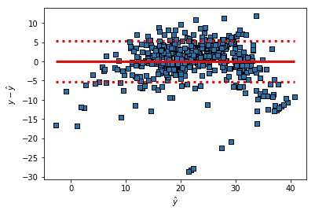

```python
# Fit top-5 features
xf_top = df_boston[top_feature_names].values

y_pred = model.fit_predict(xf_top, y)
mse5, rsq5 = evaluate_accuracy(y, y_pred)
print(f'mse5={mse5:.2f}, rsq5={rsq5:.2f}')

# Residuals plot
def plot_residuals(y, y_pred, ax=None, res_label=None):
    if ax is None:
        _, ax = plt.subplots()
    res = y - y_pred
    ax.scatter(y_pred, y_pred-y, marker='s', edgecolor='black', label=res_label)
    ax.hlines(y=0, xmin=y_pred.min(), xmax=y_pred.max(), color='red', lw=3)
    ax.hlines(y=[-res.std(), res.std()], xmin=y_pred.min(), xmax=y_pred.max(), color='red', lw=3, linestyles=':')
    ax.set_xlabel(r'$\hat{y}$')
    ax.set_ylabel(r'$y - \hat{y}$')
    if res_label is not None:
        ax.legend()
    return ax

plot_residuals(y, y_pred)

test.assertLess(mse5, 30)
```

That's better, but there's still more to be desired. Let's try to improve our model further.

### Adding nonlinear features

We can see that many of the relationships between our features and target variable are obviously not linear and cannot be modeled completely by fitting lines (or hyperplanes). Is there a way to fit a non-linear function to the data (such as a polynomial) but still use the simplicity of the Linear Regression model?

A Linear Regression model actually only needs to be linear in the **parameters** of the model. It doesn't care what possibly nonlinear relationships exists between the feature values. This means that we can increase the **capacity** of our model (its ability to fit a wide variety of functions) by adding more parameters that correspond to non-linear transformations of the features.

Suppose we have 2-dimensional feature vectors, $\vec{x}=(x_1, x_2)$. We can fit a linear regression model with 3 parameters which represent some 2-d plane. However if we transform each such feature vector, for example by $\vec{\tilde{x}} = (x_1, x_2, x_1^2, x_1 x_2, x_2^2)$ then we can now fit a model with 6 parameters to the same data. These parameters still represent a hyperplane, but in a higher dimensional space which combines the original features. Thus, when looking at the prediction surface in the original 2-d space, we'll see that the model actually fitted a non-linear surface instead of a 2-d plane - in this example a second order polynomial. The model is still linear, since the prediction method is now $\hat{y} = \vectr{w}\vec{\tilde{x}} + b$, but it's capacity has been increased.

Let's implement some hand-crafted nonlinear features based on all the features in the dataset. This step in the machine learning process is sometimes also referred to as feature engineering. In the rest of the course, you'll see how Deep Learning allows us to learn the features themselves instead of creating them by hand, and thus creating very powerful representations.

**TODO** Implement the `BostonFeaturesTransformer` class in the `hw1/linear_regression.py` module. You can create any features you want, for example given $\vec{x}=(x_1,x_2)$ you could generate features such as $x_1^2$, $x_1 \log{x_2}$, $e^{-x_1}$ and so on. Try to infer relationships based on the scatter matrix.

Notes:

- You can use the class `PolynomialFeatures` from `sklearn.preprocessing` to simplify generation of polynomial features.
- Removing a feature is also a new feature. You can discard features if they're not helpful.

```
mse=8.09, rsq=0.90
```

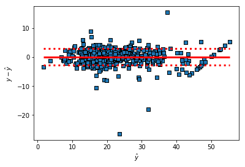

```python
def linreg_boston(model, x, y, fit=True):
    if fit:
        model.fit(x, y)
    y_pred = model.predict(x)
    mse, rsq = evaluate_accuracy(y, y_pred)
    return y_pred, mse, rsq

# Fit with all features this time
x = df_boston[feature_names].values

# Use model with a custom features transform
model = sklearn.pipeline.make_pipeline(
    hw1linreg.BiasTrickTransformer(),
    hw1linreg.BostonFeaturesTransformer(),
    hw1linreg.LinearRegressor()
)
#7.53 0.91
y_pred, mse, rsq = linreg_boston(model, x, y)
print(f'mse={mse:.2f}, rsq={rsq:.2f}')

# Test: You should get at least 2x lower loss than previously, easily even lower
plot_residuals(y, y_pred)
test.assertLess(mse, mse5 / 2)
```

### Generalization

By now, your model should produce fairly accurate predictions. Note howerver that we trained it on the entire Boston dataset.

When training models, we don't actually care about their performance on the training data; we're not interested in solving optimization problems. What we want is the ability to **generalize**: How well will it perform on novel, unseen data? In other words, did the model learn some function similar to the one actually generating the samples?

Let's find out how good our model is for unseen data the usual way: We'll split our dataset into a training and test set.

```python
from sklearn.model_selection import train_test_split

# Data and model
x = df_boston[feature_names].values
y = df_boston['MEDV'].values
x_train, x_test, y_train, y_test = train_test_split(x, y, test_size=0.2)

model = sklearn.pipeline.make_pipeline(
    hw1linreg.BiasTrickTransformer(),
    hw1linreg.BostonFeaturesTransformer(),
    hw1linreg.LinearRegressor()
)
```

However, instead of just fitting the model on the training set and evaluating on the test set, we'll use cross-validation to find a set of model hyperparameters that allow the model to generalize well. We'll again use k-fold CV to split the training set into k-folds where for each set of hyperparameters being tested, each time one of the folds is treated like the test set and the model is fitted to the rest.

**TODO** Implement the `cv_best_hyperparams()` function in the `hw1/linear_regression.py` module.

```python
# Define search-spaces for hyper parameters
degree_range = np.arange(1, 4)
lambda_range = np.logspace(-3, 2, base=10, num=20)

# Use cross-validation to find best combination of hyperparameters
best_hypers = hw1linreg.cv_best_hyperparams(model, x_train, y_train, k_folds=3,
                                            degree_range=degree_range, lambda_range=lambda_range)

print('Best hyperparameters: ', best_hypers)

# Make sure returned params exist in the model
for param in best_hypers.keys():
    test.assertIn(param, model.get_params())
```

```
60
Best hyperparameters:  {'bostonfeaturestransformer__degree': 2, 'linearregressor__reg_lambda': 0.42813323987193913}
```

Now lets use the best hyperparameters to train a model on the training set and evaluate it on the test set.

```
train: mse=7.08, rsq=0.92
test:  mse=20.04, rsq=0.64
```

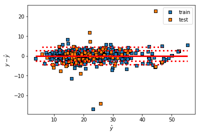

```python
# Use the best hyperparameters
model.set_params(**best_hypers)

# Train best model on full training set
y_pred_train, mse, rsq = linreg_boston(model, x_train, y_train)
print(f'train: mse={mse:.2f}, rsq={rsq:.2f}')
ax = plot_residuals(y_train, y_pred_train, res_label='train')

# Evaluate on test set
y_pred_test, mse, rsq = linreg_boston(model, x_test, y_test, fit=False)
print(f'test:  mse={mse:.2f}, rsq={rsq:.2f}')
ax = plot_residuals(y_test, y_pred_test, ax=ax, res_label='test')

# Make sure test-set accuracy is sane
test.assertLess(mse, 25) # You should be able to get way below this
```

### Questions

**TODO** Answer the following questions. Write your answers in the appropriate variables in the module `hw1/answers.py`.

```python
from cs236605.answers import display_answer
import hw1.answers
```

#### Question 1

Whats the ideal pattern to see in a residual plot? Based on the residual plots you got above, what can you say about the fitness of the trained model? Compare the plot for the top-5 features with the final plot after CV.

```python
display_answer(hw1.answers.part4_q1)
```

we would like to see that all points are along the line y=0 meaning that the difference between the pridected value and the actual value is almost 0.

#### Question 2

Regarding the cross-validation:

1. When defining the range for $\lambda$ the in the above CV code, why do you think we used `np.logspace` instead of `np.linspace`?
2. How many times in total was the model fitted to data (with the parameters as given and not including the final fit on the entire training set)?

```python
display_answer(hw1.answers.part4_q2)
```

because the regularization loss is less effected by lambda compared to w, eg. small change in lambda will drasticly changge the loss. but in logspace small change in the value will yield much larger results enabling us to travese a large interval quickly.

in total we tried 60 combinations of hyperParams: 3 polynom degrees and 20 lambda values